# Data handling and visualization using Python

Oleksandr (Sasha) Huziy, Jonathan Doyle, Martin Deshaies-Jacques

CMOS, June 2014

[figure not shown]

# Outline part I

- **Python basics**
  - Builtin data types
  - Operations on file system, strings and dates
  - Modules, classes and functions
- **Libraries for scientific computing**
  - NumPy/SciPy
- **Handling NetCDF4 files**
  - Netcdf4-python

# Introduction and history

### Python is an interpreted, strictly typed programming language developed by *Guido Van Rossum*.

### Python is a glue language that permits to tie together Fortran, C and C++ libraries and use their power in a comfort of the Python environment.

### There many implementations of Python (in C, Java, Python, ...), CPython implementation is used most widely and we are going to use it during the tutorial.

### Talk on Python history by Guido Van Rossum [here](http://www.youtube.com/watch?v=ugqu10JV7dk).

# Some things I've done with python: lake level observations

- [View the demo](https://maps.google.com/maps?q=http://people.sca.uqam.ca/~huziy/mon.kml)
- [View the source code](https://github.com/guziy/RPN/blob/master/src/google_maps/googlecharts.py)

# Clickable map

- [View the demo](http://scaweb.sca.uqam.ca/~huziy/pf_images_10yr/pf.htm)
- [View the code](https://github.com/guziy/RPN/blob/master/src/permafrost/plot_soiltemp_cross.py)

# More cool examples:

- [matplotlib](http://matplotlib.org/gallery.html)
- [PyNGL](http://www.pyngl.ucar.edu/Examples/gallery.shtml)
- [Cartopy](http://scitools.org.uk/cartopy/docs/latest/gallery.html)

# Syntax

```python
#Variable decalaration <-This is a comment
a = 10; b = "climate"; x = None;

x = [1,2,4, 5, "I am a fifth element"]
#looping
for el in x:
    #Checking conditions
    if isinstance(el, int):
        print(el ** 2 % 10),
    else:
        msg = ", but my index is {0}."
        msg = msg.format(x.index(el))
        print(el + msg),

#now we are outside of the loop since no identation
print "\nSomething ..."
```

```
1 4 6 5 I am a fifth element, but my index is 4.
Something ...
```

# Syntax

```python
#accessing elements of a list
x[3], x[-1], x[1:-1]
```

```
(5, 'I am a fifth element', [2, 4, 5])
```

## Defining functions

```python
def myfirst_func(x, name = "Default value of the parameter name"):
    """
    This is the comment describing method
    arguments and what it actually does
    x - dummy argument that demonstrates
    use of positional arguments
    name - demonstrates use of keyword arguments
    """
    print "Hello {0} !!!".format(name)
    return 2, None, x, "You can return many things from functions"
```

## Calling functions

```python
#Calling the function myfirst_func
myfirst_func("anything", name = "Not default name");
```

```
Hello Not default name !!!
```

# Python basics - code hierarchy

- Each python file is a python module, it can contain function and class definitions
- A folder with python files and a file `__init__.py` (might be empty file) is called package. Different packages and modules arelinked using `import`statement.

# Exercises on basic syntax

- Create a script `hello.py` in your favourite editor and add a function say_hello with a keyword argument name, which prints "hello --value of the parameter name--". Run it: `python hello.py`
- Use the function say_hello in another module. (i.e create file use_hello.py and call the say_hello function from there)
- Modify the script making it print squares of odd numbers from 13 to 61 inclusively.
- What will this code print:

```
    print 5/2
    print 10 * [18,]
    print 5 * "123"
```

# Builtin data containers

## Python provides the following data structures. Which are actually classes with attributes and methods.

- `list` (range, *, +, pop, len, accessing list elements, slices, last element, 5 last elements)
- `tuple` (not mutable, methods)
- `dict` (accessing elements, keys, size)
- `set` (set theoretical operations, cannot have 2 equal elements)

# Builtin data containers (lists)

```python
#lists (you can conactenate and sort in place)
the_list = [1,2,3,4,5]; other_list = 5 * [6];
print the_list + other_list
```

```
[1, 2, 3, 4, 5, 6, 6, 6, 6, 6]
```

```python
#Test if a number is inside a list
print 19 in the_list, 5 in the_list, (6 in the_list and 6 in other_list)
```

```
False True False
```

# Builtin data containers (lists)

```python
#square eleaments of a list
#list comprehension
print [the_el ** 2 for the_el in the_list]
```

```
[1, 4, 9, 16, 25]
```

```python
#Generating list or iterable of integers
print range(1,20)
```

```
[1, 2, 3, 4, 5, 6, 7, 8, 9, 10, 11, 12, 13, 14, 15, 16, 17, 18, 19]
```

# Builtin data containers (lists)

```python
##There are some utility functions that can be applied to lists
print "list sum:", sum(the_list)
print "list product: ", reduce(lambda x, y: x * y, the_list)
```

```
list sum: 15
list product:  120
```

```python
#loop through several lists at the same time
for el1, el2 in zip(the_list, other_list):
    print(el1+el2),
```

```
7 8 9 10 11
```

# Builtin data containers (tuples)

```python
the_tuple = (1,2,3) #tuple is an immutable list, is hashable
print the_tuple[-1]
```

```
3
```

# Builtin data containers (tuples)

```python
#tuples are immutable, e.g:
try:
    the_tuple[1] = 25
except TypeError, te:
    print te
#By the way this is the way exceptions are handled in python 2.7
#To throw an exception use raise Exception("Time to halt!!")
```

```
'tuple' object does not support item assignment
```

# Builtin data containers (dictionary)

```python
#dictionary
author_to_books = {
"Stephen King":
    ["Carrie","On writing","Green Mile"],

"Richard Feynman":
    ["Lectures on computation",
     "The pleasure of finding things out"]
}
#add elements to a dictionary
author_to_books["Andrey Kolmogorov"] = \
        ["Foundations Of The Theory Of Prob..."]
```

# Builtin data containers (dictionary)

```python
#print the list of authors
print author_to_books.keys()
```

```
['Stephen King', 'Richard Feynman', 'Andrey Kolmogorov']
```

```python
#Iterate over keys and values
for author, book_list in author_to_books.iteritems():
    suffix = "s" if len(book_list) > 1 else ""
    print("{0} book{1} by {2};\n".format(len(book_list), suffix, author)),
```

```
3 books by Stephen King;
2 books by Richard Feynman;
1 book by Andrey Kolmogorov;
```

# Exercises: builtin containers

- Find a sum of squares of all odd integers that are smaller than 100 in one line of code (Hint: use list comprehensions)
- Find out what does `enumerate` do.
- Implement recursive fibonacci function with caching, which given the index of a fibonacci number returns its value.

# Modules and classes to operate on

- File system (`os, shutil, sys`)
  - create folder, list folder contents, check if file or folder exists
- Strings (+, *, join, split, regular expressions)
- Dates (datetime, timedelta, )

# File system

```python
import os
#print current directory
print os.getcwd()
```

```
/home/san/Python/CMOS-python-tutorial
```

# File system

```python
#get list of files in the current directory
flist = os.listdir(".")
print flist[:7]
```

```
['test.nc', 'custom.css', 'norm.daily.nao.index.b500101.current.ascii', 'images', 'default_transition.tpl', 'countries', 'monthly_mean_qc_0.1_1979_05_PR.rpn.nc']
```

# File system

```python
#Check if file exists
fname = flist[0]
print fname,":", os.path.isfile(fname), \
      os.path.isdir(fname),  \
      os.path.islink(fname)
```

```
test.nc : True False False
```

You might also find useful the following modules: `sys, shutil, path`

# Strings

```python
s = "climate"
#reverse (also works for lists)
print s[-1::-1]
```

```
etamilc
```

```python
#Dynamically changing parts of a string (for left right justification use '>', '<')
tpl = "Formatting floats: {0:.3f};\nformatting integers: {1:05d};\nformatting dates: {2: %Y-%m-%d %H:%M}"
print tpl.format(789.3342353554, 32, datetime.now())
```

```
Formatting floats: 789.334;
formatting integers: 00032;
formatting dates:  2014-04-13 20:29
```

# Strings

```python
#Splitting
s = "This,is,a,sentence"
s_list = s.split(",")
print s_list
```

```
['This', 'is', 'a', 'sentence']
```

# Strings

```python
#joining a list of strings
list_of_fruits = ["apple", "banana", "cherry"]
x =   """
        I would like to eat
        {0}.
        And by the way I am a multiline string.
      """
print x.format(" or ".join(list_of_fruits))
```

```
        I would like to eat
        apple or banana or cherry.
        And by the way I am a multiline string.
```

# Strings: regular expressions

```python
#regular expressions module
import re
msg = "Find 192, numbers 278: and -7 and do smth w 89"
groups = re.findall(r"-?\d+", msg)
print groups
print [float(el) for el in groups] #convert strings to floats
```

```
['192', '278', '-7', '89']
[192.0, 278.0, -7.0, 89.0]
```

```python
#regular expressions module
groups = re.findall(r"-?\d+/\d+|-?\d+\.\d+|-?\.?\d+|-?\d+\.?", "Find 192.28940, -2/3 numbers 278: and -7 and .005 w 89,fh.5 -354.")
print groups
```

```
['192.28940', '-2/3', '278', '-7', '.005', '89', '.5', '-354']
```

# Dates

```python
#What time is it
from datetime import datetime, timedelta
d = datetime.now(); print d
```

```
2014-04-13 20:29:26.029591
```

```python
#hours and minutes
d.strftime("%H:%M"), d.strftime("%Hh%Mmin")
```

```
('20:29', '20h29min')
```

# Dates: How long is the CMOS 2014?

```python
start_date = datetime(2014, 6, 1, 8, 30)
end_date = datetime(2014, 6, 5, 17)
print end_date - start_date
```

```
4 days, 8:30:00
```

```python
#you can mutiply the interval by an integer
print (end_date - start_date) * 2
```

```
8 days, 17:00:00
```

# Exercises: Operations with strings, dates and file system

- Get list of all items in the folders from your `LD_LIBRARY_PATH` environment variable
- Write a function that finds all the numbers in a string using `re` module (Note: make sure real numbers are also accounted for. Optionally you can also account for the fractions like 2/3)
- Calculate your age in weeks using `timedelta`
- Figure out on which day of week you were born (see the `calendar` module), you can have fun by determining on which day of week you'll have your birthday in 2014.

# NumPy

The library for fast manipulations with big arrays that fit into memory.

```python
import numpy as np
#Creating a numpy array from list
np_arr = np.asarray([1,23,4, 3.5,6,7,86, 18.9])
print np_arr
print np_arr + 1
print np_arr ** 2
print np_arr + 5 * np_arr
```

```
[  1.   23.    4.    3.5   6.    7.   86.   18.9]
[  2.   24.    5.    4.5   7.    8.   87.   19.9]
[  1.00000000e+00   5.29000000e+02   1.60000000e+01   1.22500000e+01
   3.60000000e+01   4.90000000e+01   7.39600000e+03   3.57210000e+02]
[   6.   138.    24.    21.    36.    42.   516.   113.4]
```

# NumPy

```python
#Reshape
np_arr.shape = (2,4)
print np_arr
```

```
[[  1.   23.    4.    3.5]
 [  6.    7.   86.   18.9]]
```

```python
#sum along a specified dimension, here
print np_arr.sum(axis = 1)
```

```
[  31.5  117.9]
```

# Numpy

```python
#create prefilled arrays
the_zeros = np.zeros((3,9))
the_ones = np.ones((3,9))

print the_zeros
print 20 * "-"
print the_ones
```

```
[[ 0.  0.  0.  0.  0.  0.  0.  0.  0.]
 [ 0.  0.  0.  0.  0.  0.  0.  0.  0.]
 [ 0.  0.  0.  0.  0.  0.  0.  0.  0.]]
--------------------
[[ 1.  1.  1.  1.  1.  1.  1.  1.  1.]
 [ 1.  1.  1.  1.  1.  1.  1.  1.  1.]
 [ 1.  1.  1.  1.  1.  1.  1.  1.  1.]]
```

# Numpy provides many vectorized functions to efficiently operate on arrays

```python
print np.sin(np_arr)
```

```
[[ 0.84147098 -0.8462204  -0.7568025  -0.35078323]
 [-0.2794155   0.6569866  -0.92345845  0.05042269]]
```

```python
print np.cross([1,0,0], [0,1,0])
```

```
[0 0 1]
```

# Numpy: fancy indexing

```python
arr = np.random.randn(3,5)
print "Sum of positive numbers: ", arr[arr > 0].sum()

print "Sum over (-0.1 <= arr <= 0.1): ", \
       arr[(arr >= -0.1) & (arr <= 0.1)].sum()

print "Sum over (-0.1 > arr) or (arr > 0.1): ", \
       arr[(arr < -0.1) | (arr > 0.1)].sum()
```

```
Sum of positive numbers:  2.1630311989
Sum over (-0.1 <= arr <= 0.1):  0.0521362096431
Sum over (-0.1 > arr) or (arr > 0.1):  -8.14702898694
```

# Exercises: Numpy

- TODO: correlation field from 2 3d fields.
- Generate a 10 x 3 array of random numbers (in range [0,1]). For each row, pick the number closest to 0.5 ([source](http://scipy-lectures.github.io/intro/numpy/exercises.html#array-manipulations)) *Hint:* use `np.argmin`.
- Checkout numpy for MATLAB users transition [table](http://wiki.scipy.org/NumPy_for_Matlab_Users).

# SciPy packages

It contains many packages useful for data analysis

| Package | Purpose |
| --- | --- |
| scipy.cluster | Vector quantization / Kmeans |
| scipy.constants | Physical and mathematical constants |
| scipy.fftpack | Fourier transform |
| scipy.integrate | Integration routines |
| scipy.interpolate | Interpolation |
| scipy.io | Data input and output |
| scipy.linalg | Linear algebra routines |
| scipy.ndimage | n-dimensional image package |

# SciPy packages (cont.)

It contains many packages useful for data analysis

| Package | Purpose |
| --- | --- |
| scipy.odr | Orthogonal distance regression |
| scipy.optimize | Optimization |
| scipy.signal | Signal processing |
| scipy.sparse | Sparse matrices |
| scipy.spatial | Spatial data structures and algorithms |
| scipy.special | Any special mathematical functions |
| scipy.stats | Statistics |

# SciPy: ttest example

```python
from scipy import stats
#generating random variable samples for different distributions
x1 = stats.norm.rvs(loc = 50, scale = 20, size=100)
x2 = stats.norm.rvs(loc=5, scale = 20, size=100)
print stats.ttest_ind(x1, x2)

x1 = stats.norm.rvs(loc = 50, scale = 20, size=100)
x2 = stats.norm.rvs(loc=45, scale = 20, size=100)
print stats.ttest_ind(x1, x2)
```

```
(array(15.342421553977859), 1.5945963127868084e-35)
(array(1.816641809723641), 0.07078411720592058)
```

# SciPy: integrate a function

$$ \int\limits_{-\infty}^{+\infty} e^{-x^2}dx \;=\; ? $$

```python
from scipy import integrate
```

```python
def the_func(x):
    return np.exp(-x ** 2)
print integrate.quad(the_func, -np.Inf, np.inf)
```

```
(1.7724538509055159, 1.4202636780944923e-08)
```

```python
print "Exact Value sqrt(pi) = {0} ...".format(np.pi ** 0.5)
```

```
Exact Value sqrt(pi) = 1.77245385091 ...
```

# Exercises: SciPy

- Calculate the integral over the cube D=[0,1] x [0, 1] x [0,1] ([source](http://scipy-lectures.github.io/intro/numpy/exercises.html)):

  $$ \int\int\limits_{D}\int \left(x^y -z \right) dD $$

  *Hint: checkout* `scipy.integrate.tplquad`.

# Netcdf4-python

## The python module that for reading and writing NetCDF files in python, created by *Jeff Whitaker*.

## Requires installation of C libraries:

- **NetCDF4**
- **HDF5**

# Netcd4-python

## Below is the example of creating a netcdf file using the **netcdf4-python** library.

```python
from netCDF4 import Dataset
file_name = "test.nc"
if os.path.isfile(file_name):
    os.remove(file_name)

#open the file for writing, you can Also specify format="NETCDF4_CLASSIC" or "NETCDF3_CLASSIC"
#The format is NETCDF4 by default
ds = Dataset(file_name, mode="w")
```

# Netcdf4-python: create dimensions

```python
ds.createDimension("x", 20)
ds.createDimension("y", 20)
ds.createDimension("time", None)
```

```
<netCDF4.Dimension at 0x5d9b050>
```

# Netcdf4-python: create variables

```python
var1 = ds.createVariable("field1", "f4", ("time", "x", "y"))
var2 = ds.createVariable("field2", "f4", ("time", "x", "y"))

#add netcdf attributes
var1.units = "m/s"
var1.long_name = "zonal wind speed"
```

# Write actual data to the file

```python
#generate random data and tell to the program where it should go
data = np.random.randn(10, 20, 20)
var1[:] = data
var2[:] = 10 * data + 10
#actually write data to the disk
ds.close();
```

```python
%%bash
#check the file header:
ncdump -h test.nc
```

```
netcdf test {
dimensions:
	x = 20 ;
	y = 20 ;
	time = UNLIMITED ; // (10 currently)
variables:
	float field1(time, x, y) ;
		field1:units = "m/s" ;
		field1:long_name = "zonal wind speed" ;
	float field2(time, x, y) ;
}
```

# Netcdf4-python: reading a netcdf file

Open the netcdf file for reading:

```python
from netCDF4 import Dataset
ds = Dataset("test.nc")
```

# Select variables of interest: no data loading happens at this point

```python
#what variables are in the file
print ds.variables.keys()

#now data is a netcdf4 Variable object, which contain only links to the data
data1_var = ds.variables["field1"]
data2_var = ds.variables["field2"]
#You can query dimensions and shapes of the variables
print data1_var.dimensions, data1_var.shape
```

```
[u'field1', u'field2']
(u'time', u'x', u'y') (10, 20, 20)
```

# Read data from the netcdf file for corresponding variables and time steps

```python
#now we ask to really read the data into the memory
all_data = data1_var[:]
#print all_data.shape
data1 = data1_var[1,:,:]
data2 = data2_var[2,:,:]
print data1.shape, all_data.shape, all_data.mean(axis = 0).mean(axis = 0).mean(axis = 0)
```

```
(20, 20) (10, 20, 20) 0.0035528
```

# Outline part II

- **Plotting libraries**
  - Matplotlib
  - Basemap
- **Grouping and subsetting temporal data with `pandas`**
- **Interpolation using `cKDTree` (`KDTree`) class**
- **Speeding up your code**

# Matplotlib

## The module for creating publication quality plots (mainly 2D), created by *John Hunter*.

## [Matplotlib gallery](http://matplotlib.org/gallery.html)

An alternative is PyNGL - a wrapper around NCL developed at NCAR.

# Matplotlib

Example taken from the matplotlib library and modified.

Read some timeseries into memory and import external dependencies:

```python
import matplotlib.pyplot as plt
from datetime import datetime
import matplotlib.cbook as cbook
from matplotlib.dates import strpdate2num
from matplotlib.dates import DateFormatter
from matplotlib.dates import DayLocator, MonthLocator

datafile = cbook.get_sample_data('msft.csv', asfileobj=False)
dates, closes = np.loadtxt(datafile, delimiter=',',
    converters={0: strpdate2num('%d-%b-%y')},
    skiprows=1, usecols=(0,2), unpack=True)
```

# Plot timeseries

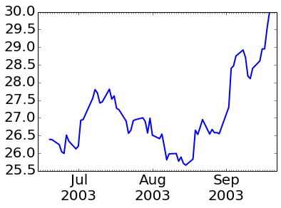

```python
fig = plt.figure()
ax = fig.add_subplot(111)
ax.plot(dates, closes, lw = 2)

ax.xaxis.set_major_formatter(DateFormatter("%b\n%Y"))
ax.xaxis.set_minor_locator(DayLocator())
ax.xaxis.set_major_locator(MonthLocator())
```

# Let us draw the data we just saved to the netcdf file.

Do necessary imports and create configuration objects.

```python
import matplotlib.pyplot as plt
from matplotlib.colors import BoundaryNorm
from matplotlib import cm

levels = [-30,-10, -3,-1,0,1,3,10,30,40]
bn = BoundaryNorm(levels, len(levels) - 1)
cmap = cm.get_cmap("jet", len(levels) - 1);
```

# Matplotlib: plotting 2 fields with nonlinear and shared colorbar

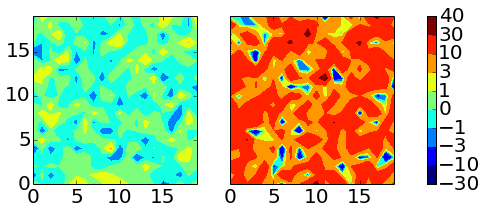

```python
fig, axes = plt.subplots(nrows=1, ncols=3)
im1 = axes[0].contourf(data1.transpose(),
                       levels = levels,
                       norm = bn, cmap = cmap)
im2 = axes[1].contourf(data2.transpose(),
                       levels = levels,
                       norm = bn, cmap = cmap)
apply_some_formatting(axes, im2)
```

# Execises: Matplotlib

- Reproduce the panel plot given in the example. (Try different [colormaps](http://matplotlib.org/examples/color/colormaps_reference.html))
- Plot a timeseries of daily random data. (Show only month names as Jan, Feb, .. along the x-axis, make sure the labels do not overlap)

# Pandas

## Initially designed to process and analyse long timeseries

## Author: *Wes McKinney*

## Home page: [pandas.pydata.org](http://pandas.pydata.org/)

# Download and analyse teleconnection indexes

For pandas 1D examples we will load, plot and correlate different teleconnection indices ([source](http://www.cpc.ncep.noaa.gov/products/precip/CWlink/daily_ao_index/teleconnections.shtml)).

```python
#Set name to link mapping
name_to_link = {
"AAO" : "ftp://ftp.cpc.ncep.noaa.gov/cwlinks/norm.daily.aao.index.b790101.current.ascii",
"AO" : "ftp://ftp.cpc.ncep.noaa.gov/cwlinks/norm.daily.ao.index.b500101.current.ascii",
"NAO" : "ftp://ftp.cpc.ncep.noaa.gov/cwlinks/norm.daily.nao.index.b500101.current.ascii",
"PNA" : "ftp://ftp.cpc.ncep.noaa.gov/cwlinks/norm.daily.pna.index.b500101.current.ascii"
}
```

# Define a helper download function

```python
def download_link(url, local_path):
    if os.path.isfile(local_path):
        return

    import urllib2
    s = urllib2.urlopen(url)
    with open(local_path, "wb") as local_file:
        local_file.write(s.read())
```

```python
#Download data locally if needed
for name, link in name_to_link.iteritems():
    fname = os.path.basename(link)
    if not os.path.isfile(fname):
        download_link(link, fname)
```

```python
#Read data into memory
import pandas as pd
df_list = []
for name, link in name_to_link.iteritems():
    fname = os.path.basename(link)
    dfi = pd.DataFrame.from_csv(fname, sep = r"\s+", index_col=[0,1,2], parse_dates=False)
    dfi.columns = [name]
    dfi = dfi.select(lambda t: "*" not in t[2]) # because some data is like: 2003  4 30*******
    dfi.index = dfi.index.map(lambda t: [int(ti) for ti in t])
    dfi.index = dfi.index.map(lambda t: datetime(*t))
    df_list.append(dfi)
df = pd.concat(df_list, axis = 1)
df = df.dropna()
df.head(3) #The periods
```

|  | PNA | AAO | NAO | AO |
| --- | --- | --- | --- | --- |
| 1979-01-02 | -0.319 | -0.888 | -0.838 | -1.623 |
| 1979-01-03 | -0.561 | 0.255 | -0.538 | -1.922 |
| 1979-01-04 | -0.479 | 0.862 | -0.225 | -1.180 |

# Plot the timeseries

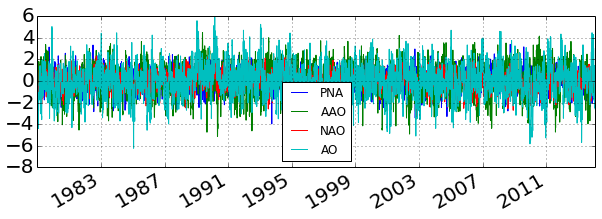

```python
df.plot();
```

# On separate panels

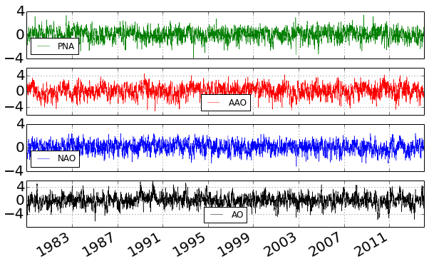

```python
axes = df.plot(subplots=True, figsize=(10,6), yticks=[-4, 0, 4], lw = 0.5,
               style = ["g", "r", "b", "k"]);
```

# What about correlations

```python
df.corr()
```

|  | PNA | AAO | NAO | AO |
| --- | --- | --- | --- | --- |
| PNA | 1.000000 | -0.007499 | 0.036017 | -0.159892 |
| AAO | -0.007499 | 1.000000 | 0.049362 | 0.048930 |
| NAO | 0.036017 | 0.049362 | 1.000000 | 0.552575 |
| AO | -0.159892 | 0.048930 | 0.552575 | 1.000000 |

# Plot monthly mean indices

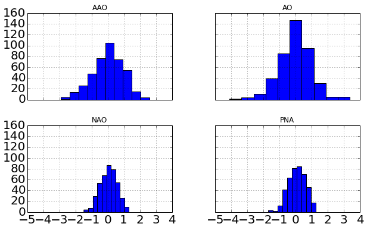

```python
df_monthly = df.groupby(by = lambda d: datetime(d.year, d.month, 15)).mean()
df_monthly.hist(figsize=(10, 6), sharex = True, sharey = True);
```

# Exercises: Pandas

- Using the data in the examples calculate seasonal or monthly climatologies of the indices and calculate correlations.
- Further reading: usually we want do time selecting, grouping, merging on 3D or 4D fields. It is also possible with pandas (Checkout Panel data container).

# Basemap

## The author is Jeff Whitaker.

## Basemap code is available on [github](https://github.com/matplotlib/basemap).

## Example [gallery](http://matplotlib.org/basemap/users/examples.html).

PyNGL - can be used as an alternative.

# The usual workflow with the library:

- **Create a basemap object**

  ```
  basemap = Basemap(projection="...", ...)
  ```

- **Draw your field using:**

  ```
  basemap.contour(), basemap.contourf(),
  basemap.pcolormesh()
  ```

- **It provides utility functions to draw coastlines, meridians and shapefiles (only those that contain lat/lon coordinates), mask ocean points.**
- **Drawing the colorbar is as easy as:**

  ```
  basemap.colorbar(img)
  ```

# Basemap

Can be used for nice map backgrounds

[figure not shown]

```python
from mpl_toolkits.basemap import Basemap
b = Basemap()
fig, (ax1, ax2) = plt.subplots(1,2)

b.warpimage(ax = ax1, scale = 0.1);
im = b.etopo(ax = ax2, scale = 0.1);
```

# Basemap: display model results in rotated lat/lon projection

```python
f_name = "monthly_mean_qc_0.1_1979_05_PR.rpn.nc"
base_url = "http://scaweb.sca.uqam.ca/~huziy/example_data"
#Fetch the file if it is not there
url = os.path.join(base_url, f_name)
download_link(url, f_name)

#read the file and check what is inside
ds_pr = Dataset(f_name)
print ds_pr.variables.keys()
```

```
[u'rlon', u'rlat', u'level', u'time', u'lon', u'lat', u'rotated_pole', u'preacc']
```

# Read data from the NetCDF file

```python
rotpole = ds_pr.variables["rotated_pole"]
lon = ds_pr.variables["lon"][:]
lat = ds_pr.variables["lat"][:]
data = ds_pr.variables["preacc"][:].squeeze()
#rotpole.ncattrs(); - returns a list of netcdf attributes of a variable
print rotpole.grid_north_pole_latitude, \
      rotpole.grid_north_pole_longitude, \
      rotpole.north_pole_grid_longitude
```

```
37.8787 106.65 176.709
```

# Creating a basemap object for the data

```python
lon_0 = rotpole.grid_north_pole_longitude - 180
o_lon_p = rotpole.north_pole_grid_longitude
o_lat_p = rotpole.grid_north_pole_latitude
b = Basemap(projection="rotpole",
            lon_0=lon_0,
            o_lon_p = o_lon_p,
            o_lat_p = o_lat_p,
            llcrnrlon = lon[0, 0],
            llcrnrlat = lat[0, 0],
            urcrnrlon = lon[-1, -1],
            urcrnrlat = lat[-1, -1],
            resolution="l")
```

# Projecting to and from the projection coordinates

```python
#(lat, lon) -> (x, y)
x, y = b(lon, lat)

#(x,y) -> (lat, lon)
loninv, latinv = b(x, y, inverse=True)
```

# Define plotting function to reuse

```python
def plot_data(x, y, data, ax):
    im = b.contourf(x, y, data, ax = ax)
    b.colorbar(im, ax = ax)
    b.drawcoastlines(linewidth=0.5);
```

# Plot the data

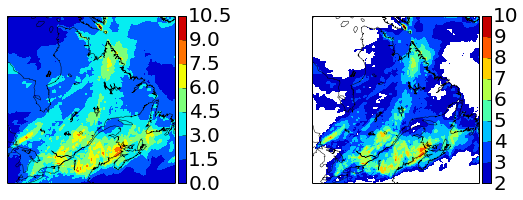

```python
fig, (ax1, ax2) = plt.subplots(1,2)
#plot data as is
plot_data(x, y, data, ax1)
#mask small values
to_plot = np.ma.masked_where(data <= 2, data)
plot_data(x, y, to_plot, ax2)
```

# Masking oceans is as easy as

```python
from mpl_toolkits.basemap import maskoceans
lon1 = lon.copy()
lon1[lon1 > 180] = lon1[lon1 > 180] - 360
data_no_ocean = maskoceans(lon1, lat, data)
```

# Plot masked field

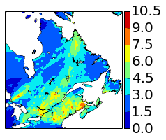

```python
fig, ax = plt.subplots(1,1)
plot_data(x, y, data_no_ocean, ax)
```

# Basemap: plotting wind field (read and convert units)

```python
download_link("http://scaweb.sca.uqam.ca/~huziy/example_data/wind.nc", "wind.nc")
ds_wind = Dataset("wind.nc")
u = ds_wind.variables["UU"][:]
v = ds_wind.variables["VV"][:]
coef_wind = 0.51444444444 #m/s in one knot
ds_wind.close()
```

# Basemap: plotting wind field

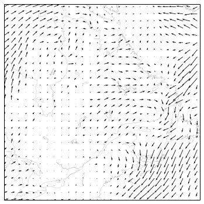

```python
fig = plt.figure()
fig.set_size_inches(6,8)
Q = b.quiver(x[::8, ::8], y[::8, ::8],
             u[::8, ::8] * coef_wind, v[::8, ::8] * coef_wind)
# make quiver key.
qk = plt.quiverkey(Q, 0.35, 0.1, 5, '5 m/s', labelpos='N',
                   coordinates = "figure",
                   fontproperties = dict(weight="bold"))
b.drawcoastlines(linewidth = 0.1);
plt.savefig("wind.png");
```

# Basemap: plotting wind field (saved image, the legend is not cropped)

[figure not shown]

# Exercises: Basemap

- Plot fields `preacc` and `air` from [here](http://scaweb.sca.uqam.ca/~huziy/example_data/wm201_Arctic_JJA_1990-2008_moyenneDesMoyennes.nc) using basemap. Add meridians and parallels as well as rivers to the map. Use subplots to put the plots side by side.
- Plot field `preacc` from [here](http://scaweb.sca.uqam.ca/~huziy/example_data/pm1989010100_00000498p_0.44deg_africa_PR.nc).

# Basemap: reading and visualizing shape files (Download data)

```python
#download the shape files directory
local_folder = "countries"
remote_folder = 'http://scaweb.sca.uqam.ca/~huziy/example_data/countries/'
if not os.path.isfile(local_folder+"/cntry00.shp"):
    urlpath = urlopen(remote_folder)
    string = urlpath.read().decode('utf-8')
    pattern = re.compile(r'cntry00\...."')
    filelist = pattern.findall(string)
    filelist = [s[:-1] for s in filelist if not s.endswith('zip"')]

    if not os.path.isdir(local_folder):
        os.mkdir(local_folder)
    for fname in filelist:
        f_path = os.path.join(local_folder, fname)
        remote_f_path = os.path.join(remote_folder, fname)
        #download selected files
        download_link(remote_f_path, f_path)
```

# Basemap: reading and visualizing shape files

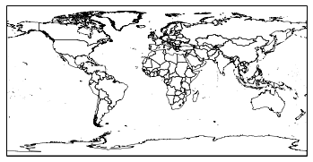

```python
bworld = Basemap()
shp_file = os.path.join(local_folder, "cntry00")
ncountries, _, _, _, linecollection = bworld.readshapefile(shp_file, "country")
```

# Reading country polygons (and attributes) from the shape file, necessary imports

```python
import fiona
from matplotlib.collections import PatchCollection
from shapely.geometry import MultiPolygon, shape
from matplotlib.patches import Polygon
import shapely
import matplotlib.cm as cm
```

# Reading country polygons (and attributes) from the shape file, preparations

```python
cmap_shape = cm.get_cmap("Greens", 10)
bounds = np.arange(0, 1.65, 0.15) * 1e9
bn_shape = BoundaryNorm(bounds, len(bounds) - 1)

bworld = Basemap()
populations = []; patches = []

def to_mpl_poly(shp_poly, apatches):
    a = np.asarray(shp_poly.exterior)
    x, y = bworld(a[:, 0], a[:, 1])
    apatches.append(Polygon(zip(x, y)))
```

# Reading country polygons (and attributes) from the shape file, preparations

```python
with fiona.open('countries/cntry00.shp', 'r') as inp:
    for f in inp:
        the_population = f["properties"]["POP_CNTRY"]
        sh = shape(f['geometry'])

        if isinstance(sh, shapely.geometry.Polygon):
            to_mpl_poly(sh, patches)
            populations.append(the_population)
        elif isinstance(sh, shapely.geometry.MultiPolygon):
            for sh1 in sh.geoms:
                to_mpl_poly(sh1, patches)
                populations.append(the_population)
```

# Coloring the countries based on the attribute value

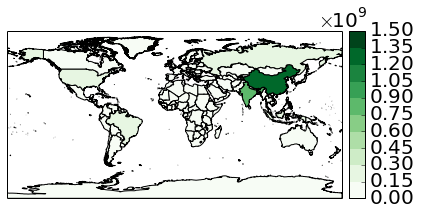

```python
from matplotlib.ticker import ScalarFormatter
sf = ScalarFormatter(useMathText=True)
fig = plt.figure(); ax = fig.add_subplot(111)
pcol = PatchCollection(patches, cmap = cmap_shape, norm = bn_shape)
pcol.set_array(np.array(populations))
ax.add_collection(pcol)
cb = bworld.colorbar(pcol, ticks = bounds, format = sf)
cb.ax.yaxis.get_offset_text().set_position((-2,0))
bworld.drawcoastlines(ax = ax, linewidth = 0);
```

# Exercise: shape files

- There is a [script](http://scaweb.sca.uqam.ca/~huziy/example_data/fiona_test.py) which is supposed to plot world population but it contains a bug. Copy it to your working directory and try to fix the bug. Try launching it and see if the produced image is correct.

# cKDTree

- Is a class defined in `scipy.spatial` package.
- Alternatives: `pyresample` and `basemap.interp`

# cKDTree - workflow

## 1. Convert all lat/lon coordinates to Cartesian coordinates

```
    (xs, ys, zs) #correspond to coordinates of the source grid
    (xt, yt, zt) #coordinates of the target grid
    #All x,y,z - are flattened 1d arrays
```

## 2. Create a cKDTree object representing source grid

```
    tree = cKDTree(data = zip(xs, ys, zs))
```

# cKDTree - workflow

## 3. Query indices of the nearest target cells and distances to the corresponding source cells

```
    dists, inds = tree.query(zip(xt, yt, zt), k = 1)
    #k = 1, means find 1 nearest point
```

## 4. Get interpolated data (and reshape it to 2D)

```
    data_target = data_source[inds].reshape(lon_target.shape)
```

# cKDTree

- For an example usage of `cKDTree`, please read my post at [earthpy.org](http://earthpy.org/interpolation_between_grids_with_ckdtree.html)
- There is a folowup to that post about `pyresample` [here](http://earthpy.org/interpolation_between_grids_with_pyresample.html).

# cKDTree: exercise

- Interpolate CRU temperatures to the model grid, use inverse distance weighting for intepolation from 20 nearest points.

  $$ T_t = \frac{\sum_{i=1}^{20}w_i T_{s,i}}{\sum_{i=1}^{20}w_i} $$

  where $w_i = 1/d_i^2$, $d_i$ - is the distance between corresponding source and target grid points. Grid longitudes and latitudes are defined in this [file](http://scaweb.sca.uqam.ca/~huziy/example_data/wind.nc). The observation temperature field is [here](http://scaweb.sca.uqam.ca/~huziy/example_data/mean_temp_cru.nc).

# Speeding up your code

- Avoid loops and try to make use of Numpy/Scipy/Pandas functionality as much as possible
- If you have a lot of computations the speedup can be achieved by delegating the computations to the NumExpr module.
- You can use Cython to compile libraries to get C-like speed.
- Use multiprocessing module if the tasks are fairly independent and cannot be solved using the above methods

# Multiprocessing example

```python
from multiprocessing import Pool

def func(x):
    return x ** 2

p1 = Pool(processes=1)
p2 = Pool(processes=2)

nums = np.arange(100000)
```

## Make sure it works correctly

```python
print p2.map(func, nums)[:10]
```

```
[0, 1, 4, 9, 16, 25, 36, 49, 64, 81]
```

## Tests of performance gain by using 2 processes instead of 1

```python
%%timeit
p1.map(func, nums)
```

```
1 loops, best of 3: 990 ms per loop
```

```python
%%timeit
p2.map(func, nums)
```

```
1 loops, best of 3: 910 ms per loop
```

# Squaring example using Numpy

```python
%%timeit
sq = nums ** 2
```

```
10000 loops, best of 3: 118 µs per loop
```

# Squaring example using NumExpr

```python
import numexpr as ne
print ne.detect_number_of_cores()
print ne.evaluate("nums ** 2")[:5]
```

```
2
[ 0  1  4  9 16]
```

```python
%%timeit
ne.evaluate("nums ** 2")
```

```
10000 loops, best of 3: 141 µs per loop
```

# Squaring example using cythonized function

```python
%load_ext cythonmagic
```

```
The cythonmagic extension is already loaded. To reload it, use:
  %reload_ext cythonmagic
```

```python
%%cython
def square_list(the_list):
    cdef list result = []
    cdef int i
    app_meth = result.append
    for i in the_list:
        app_meth(i ** 2)
    return result
```

```python
%%timeit
square_list(nums)
```

```
100 loops, best of 3: 15.1 ms per loop
```

```python
%%timeit
[i ** 2 for i in nums]
```

```
10 loops, best of 3: 128 ms per loop
```

# Resources

- Python: http://www.python.org/
- IPython: http://ipython.org/
- NumPy: http://www.numpy.org/ - there is a page NumPy for MATLAB users, might be useful for those familiar with MATLAB.
- SciPy: http://www.scipy.org/
- [Scipy lectures](http://scipy-lectures.github.io/)
- Scientific python lectures: http://scipy-lectures.github.io/
- Matplotlib: http://matplotlib.org/
- Scitools (iris and cartopy): http://scitools.org.uk/index.html

# Resources

- NetCDF4: http://netcdf4-python.googlecode.com/svn/trunk/docs/netCDF4-module.html
- Basemap: http://matplotlib.org/basemap/
- [Notebook on shape files](http://nbviewer.ipython.org/github/mqlaql/geospatial-data/blob/master/Geospatial-Data-with-Python.ipynb)
- My favourite python IDE: [Pycharm](http://www.jetbrains.com/pycharm/), you might also checkout many other like Eclipse, Netbeans, Spyder...
- On creating presentations using IPython and a lot of other things: [Damian Avilla's blog](http://www.damian.oquanta.info/index.html).